# Videogame Reviews Analysis

Arzon Francesco - 142439

## Un po’ di introduzione

I videogiochi rappresentano una enorme percentuale nel settore dell’intrattenimento. Vista l’enorme offerta tra varientà e quantità di titoli, è difficile trovare un individuo che non abbia mai giocato.  
Ma sono sempre stati così popolari?  
Quali sono considerati i migliori giochi, e quali sono le piattaforme più gettonate?

## Il dataset

In questa analisi ho utilizzato [il dataset](https://www.kaggle.com/datasets/deepcontractor/top-video-games-19952021-metacritic) contentente i punteggi degli utenti e dei ciritci di Metacritic ai videogiochi più comuni su console tra il 1995 ed il 2021, per provare a dare una risposta a queste domande.

| name | platform | meta_score | user_score | year | month |
| --- | --- | --- | --- | --- | --- |
| Sonic & All-Stars Racing Transformed | PlayStation 3 | 82 | 83 | 2012 | November |
| Darkest Dungeon | Switch | 85 | 80 | 2018 | January |
| OlliOlli2: Welcome to Olliwood | PC | 82 | 58 | 2015 | August |
| EA Sports Active 2 | Xbox 360 | 68 | 63 | 2010 | November |
| Gravity Ghost: Deluxe Edition | PlayStation 4 | 79 | 31 | 2019 | August |
| Call of Juarez: Gunslinger | Xbox 360 | 76 | 82 | 2013 | May |
| Dawn of Magic | Game Boy Advance | 52 | 59 | 2007 | October |
| Demeo | PC | 83 | 82 | 2021 | May |

## Distribuzione uscite

Si nota subito come il PC abbia un gran numero di uscite in più rispetto alle altre console…

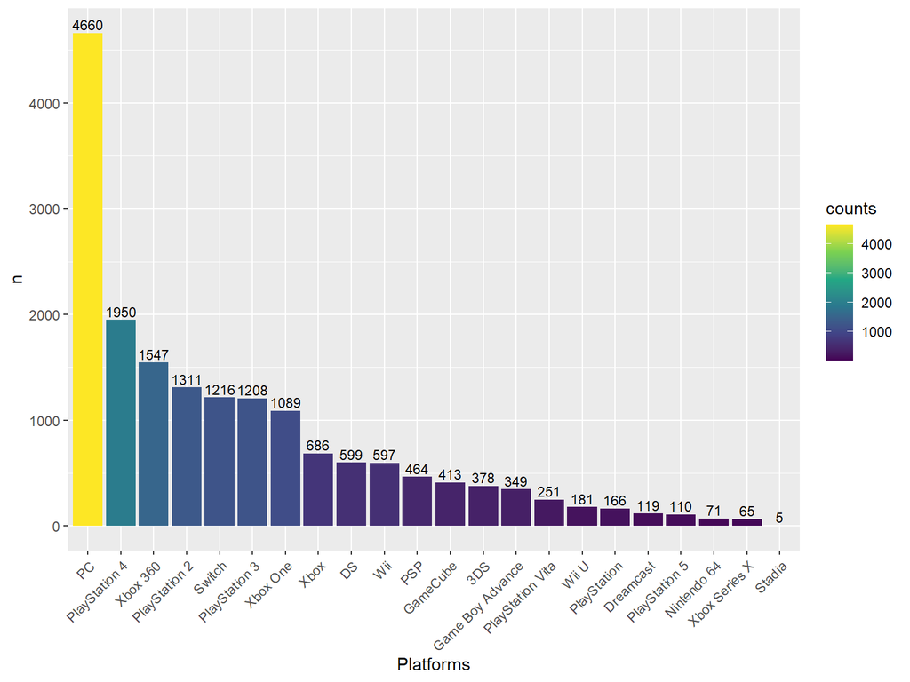

Il divario tra PC e console viene colmato se nel confronto si considerano insieme tutte le console per ogni casa produttrice; Una console diventa obsoleta con il tempo, il PC no.

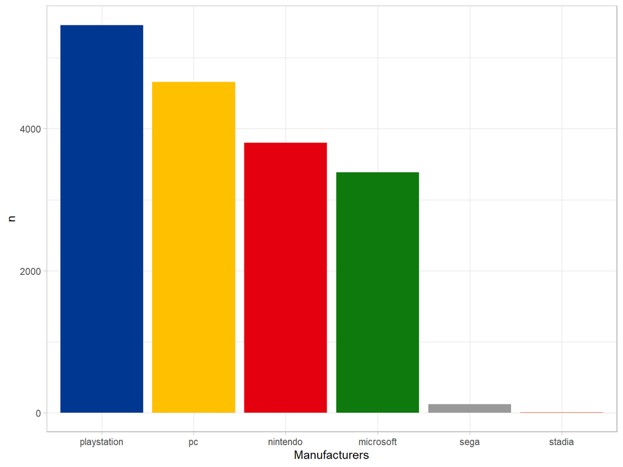

Dunque anche se singolarmente il pc ha più uscite, complessivamente le case produttrici di console riescono (più o meno) a competere.

## Nel tempo?

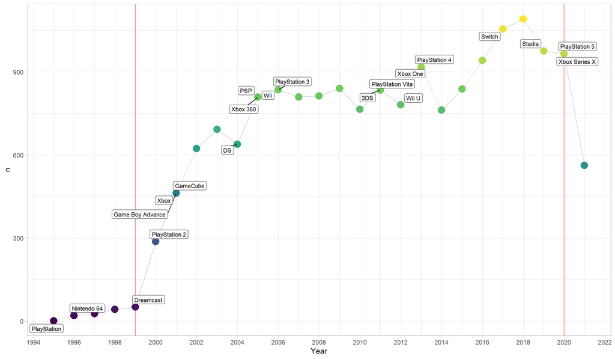

Spike nel 1999 e Drop nel 2020: che è successo?

## Ma quando vengono rilasciati i giochi?

Il dataset fornisce anche il mese di rilascio del gioco

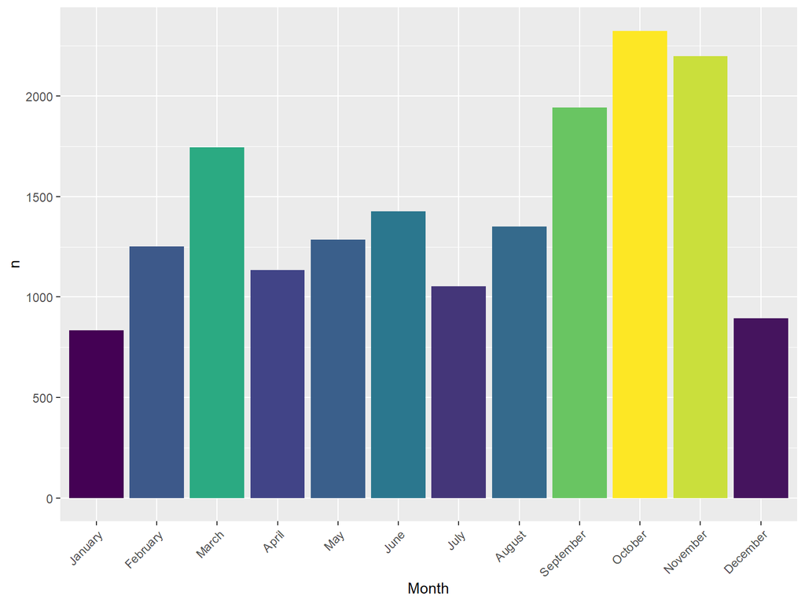

## Declino console

[interactive chart not shown]

Il grafico risulta complicato da comprendere a prima vista, perciò proviamo a dividerlo …

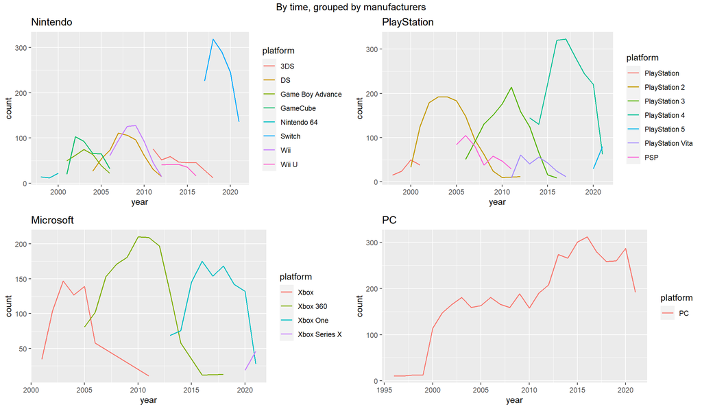

## Declino manufacturers complessivamente

[interactive chart not shown]

## Cambiamo approccio

Se finora abbiamo studiato il dataset tramite tramite uscite/periodo e le piattaforme, passiamo ad analizzare i voti asseganti ai giochi.

## Punteggio medio (Meta) per piattaforma

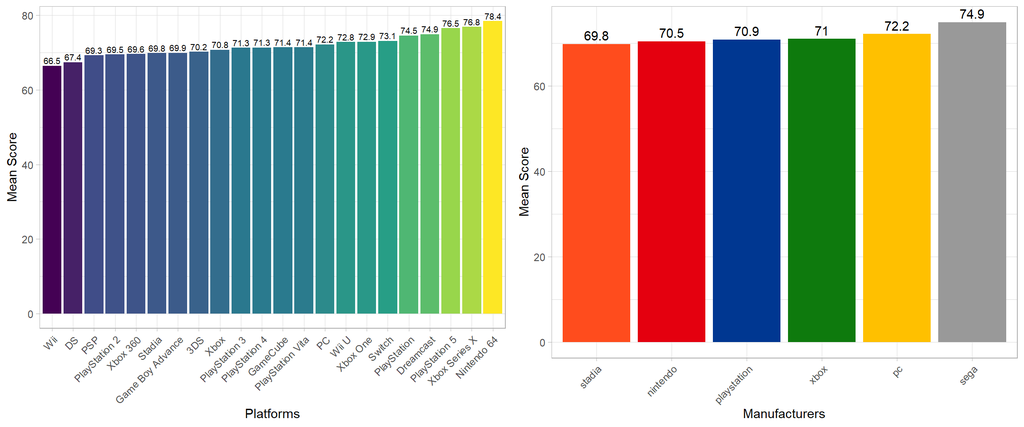

## Alcuni dati sui voti

Top 5 Metacritic

| name | platform | meta_score | user_score | year | month | group |
| --- | --- | --- | --- | --- | --- | --- |
| The Legend of Zelda: Ocarina of Time | Nintendo 64 | 99 | 91 | 1998 | November | nintendo |
| Tony Hawk’s Pro Skater 2 | PlayStation | 98 | 74 | 2000 | September | playstation |
| Grand Theft Auto IV | PlayStation 3 | 98 | 77 | 2008 | April | playstation |
| Grand Theft Auto IV | Xbox 360 | 98 | 79 | 2008 | April | microsoft |
| SoulCalibur | Dreamcast | 98 | 84 | 1999 | September | sega |

Top 5 Users

| name | platform | meta_score | user_score | year | month | group |
| --- | --- | --- | --- | --- | --- | --- |
| Ghost Trick: Phantom Detective | DS | 83 | 97 | 2011 | January | nintendo |
| Z.H.P. Unlosing Ranger vs Darkdeath Evilman | PSP | 81 | 97 | 2010 | October | playstation |
| GrimGrimoire | PlayStation 2 | 79 | 97 | 2007 | June | playstation |
| Rochard | PlayStation 3 | 79 | 97 | 2011 | September | playstation |
| After Burner Climax | Xbox 360 | 72 | 97 | 2010 | April | microsoft |

Worst 5 Metacritic

| name | platform | meta_score | user_score | year | month | group |
| --- | --- | --- | --- | --- | --- | --- |
| Infestation: Survivor Stories (The War Z) | PC | 20 | 17 | 2012 | October | pc |
| Leisure Suit Larry: Box Office Bust | PC | 20 | 20 | 2009 | March | pc |
| Afro Samurai 2: Revenge of Kuma Volume One | PlayStation 4 | 21 | 29 | 2015 | September | playstation |
| Fast & Furious: Showdown | Xbox 360 | 22 | 13 | 2013 | May | microsoft |
| Drake of the 99 Dragons | Xbox | 22 | 17 | 2003 | November | microsoft |

Worst 5 Users

| name | platform | meta_score | user_score | year | month | group |
| --- | --- | --- | --- | --- | --- | --- |
| Madden NFL 21 | PlayStation 4 | 63 | 2 | 2020 | August | playstation |
| Madden NFL 21 | Xbox One | 69 | 5 | 2020 | August | microsoft |
| Madden NFL 22 | PlayStation 5 | 68 | 5 | 2021 | August | playstation |
| Madden NFL 22 | Xbox Series X | 70 | 6 | 2021 | August | microsoft |
| Warcraft III: Reforged | PC | 59 | 6 | 2020 | January | pc |

## Critics vs Users

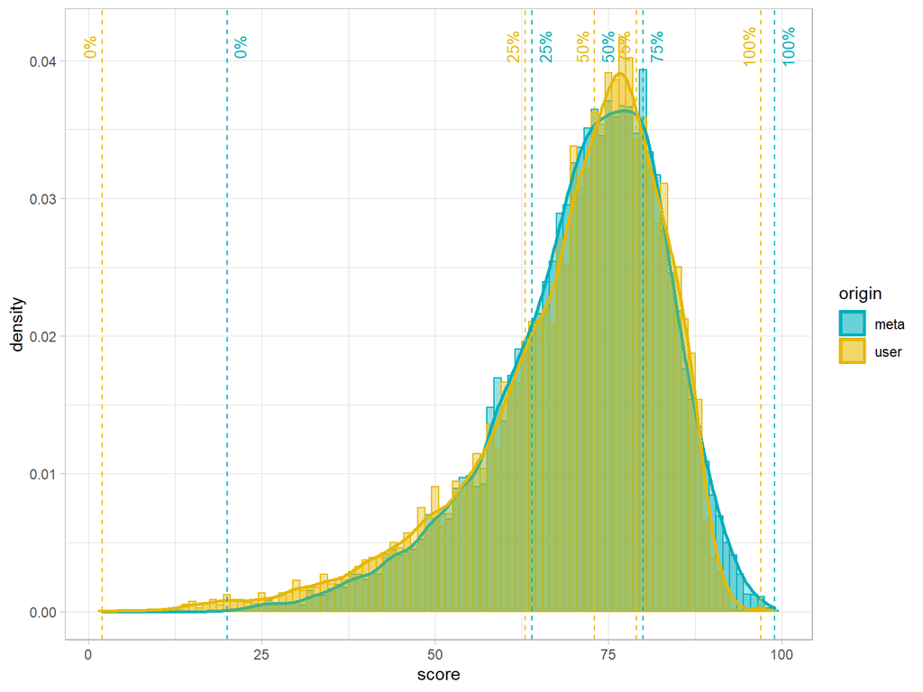

## Critics vs Users (platform)

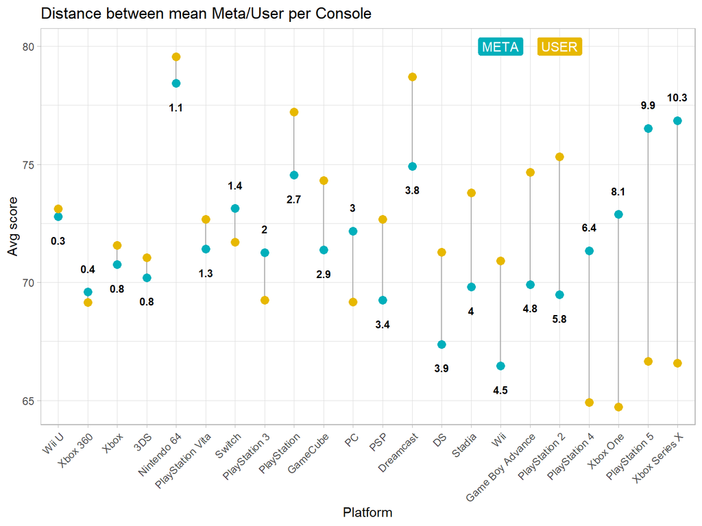

## Critics vs Users (time)

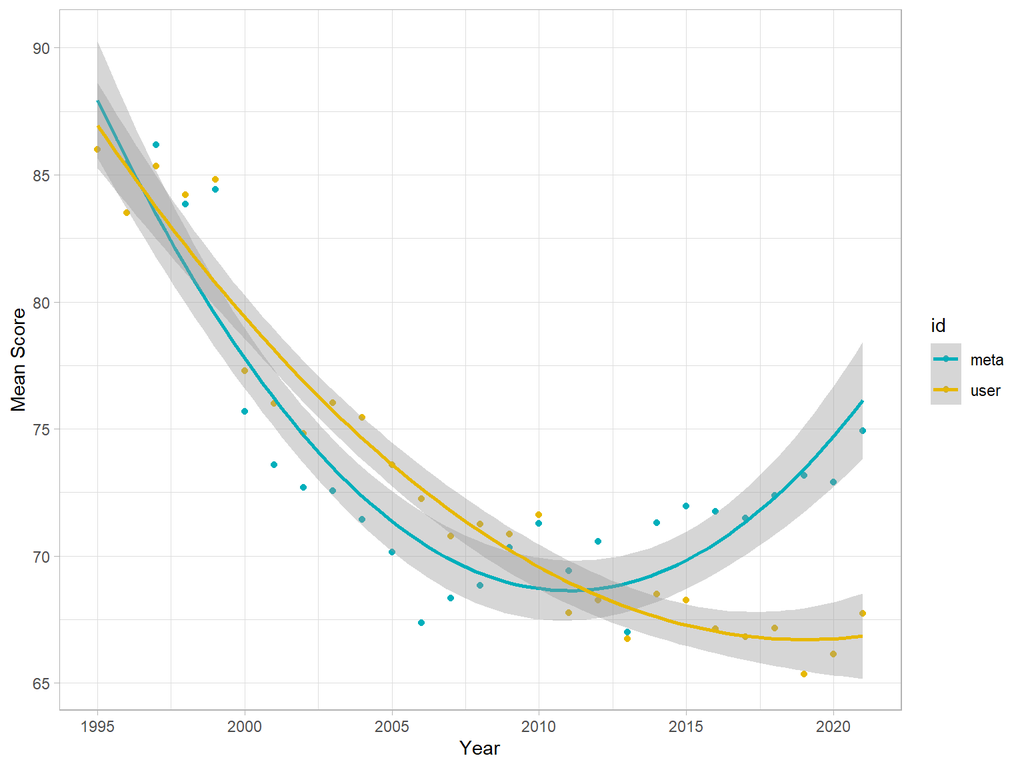

## Correlazione

C’è una buona correlazione lineare tra i due recensori. Ma è sempre stato così?

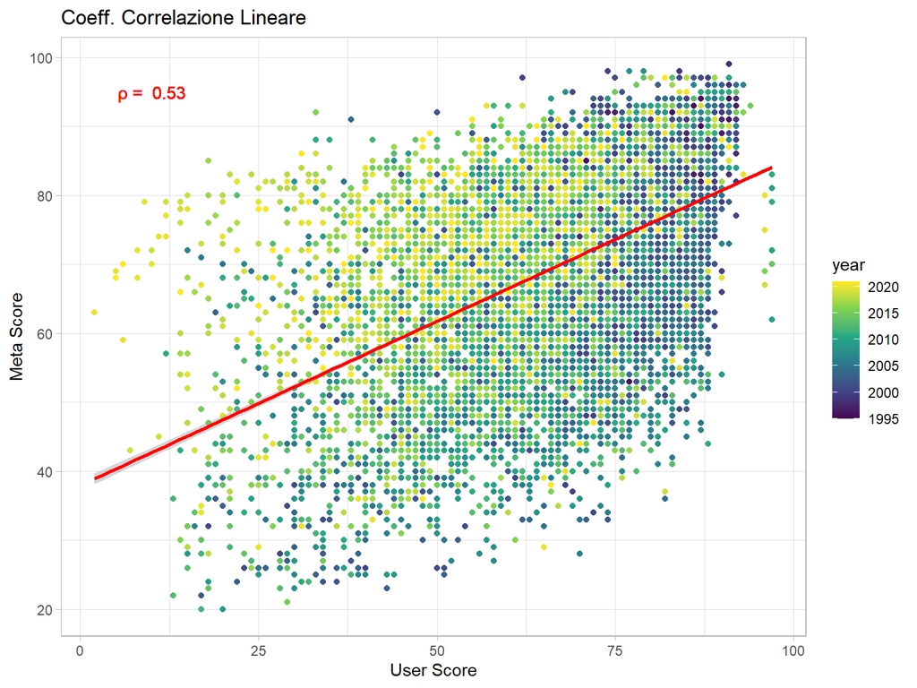

## Correlazione lineare nel tempo

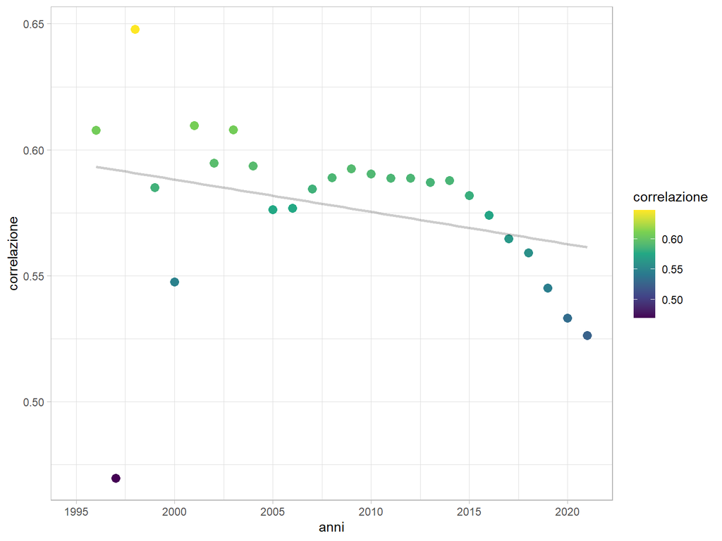

A parte una iniziale indecisione, si stabilizza e poi c’è un declino

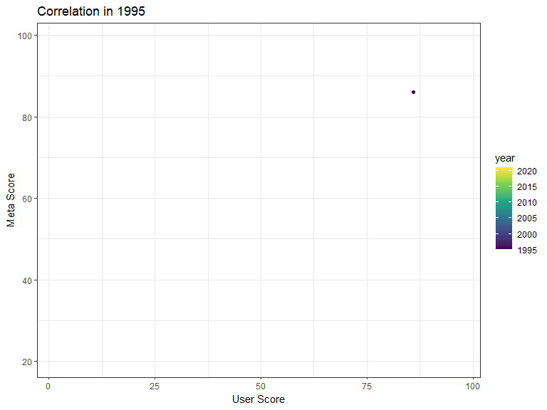

Scatterplot con modello lineare annuale

## Reviews

Infine diamo un’occhiata alle recensioni lasciate dai critici:

| name | summary |
| --- | --- |
| The Legend of Zelda: Ocarina of Time | As a young boy, Link is tricked by Ganondorf, the King of the Gerudo Thieves. The evil human uses Link to gain access to the Sacred Realm, where he places his tainted hands on Triforce and transforms … |
| Tony Hawk’s Pro Skater 2 | As most major publishers’ development efforts shift to any number of next-generation platforms, Tony Hawk 2 will likely stand as one of the last truly fantastic games to be released on the PlayStation… |
| Grand Theft Auto IV | [Metacritic’s 2008 PS3 Game of the Year; Also known as “GTA IV”] What does the American Dream mean today? For Niko Belic, fresh off the boat from Europe. It’s the hope he can escape his past. For his … |
| SoulCalibur | This is a tale of souls and swords, transcending the world and all its history, told for all eternity… The greatest weapons-based fighter returns, this time on Sega Dreamcast. Soul Calibur unleashes i… |
| Grand Theft Auto IV | [Metacritic’s 2008 Xbox 360 Game of the Year; Also known as “GTA IV”] What does the American Dream mean today? For Niko Belic, fresh off the boat from Europe. It’s the hope he can escape his past. For… |

## Top words per sentiment

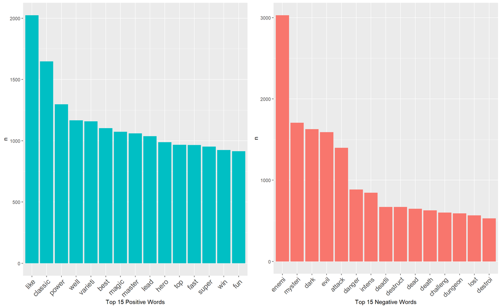

## Sentiment Analysis, by platform

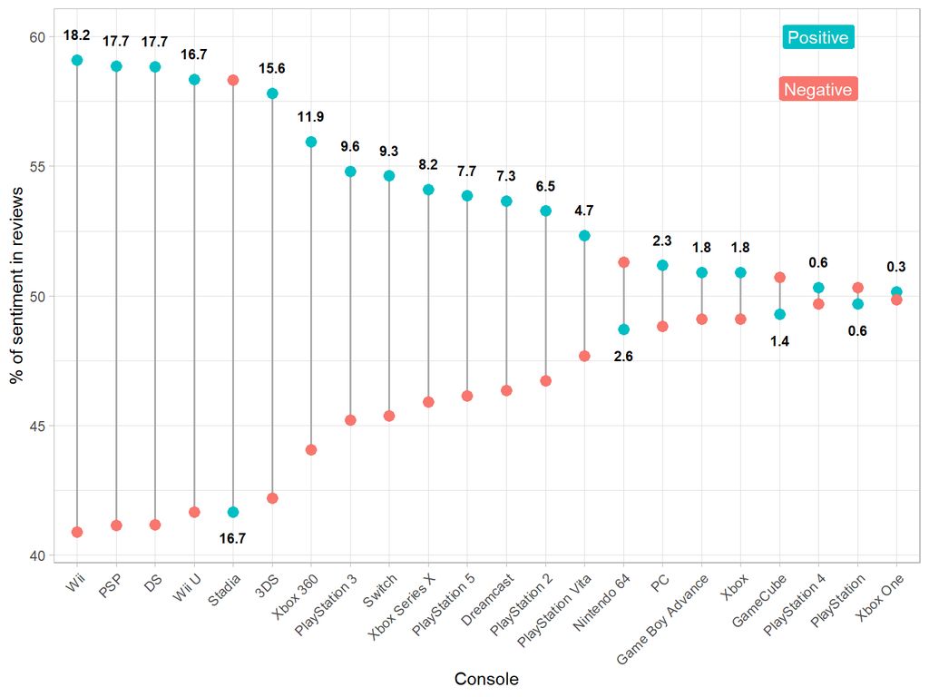

## Sentiment Analysis, by year

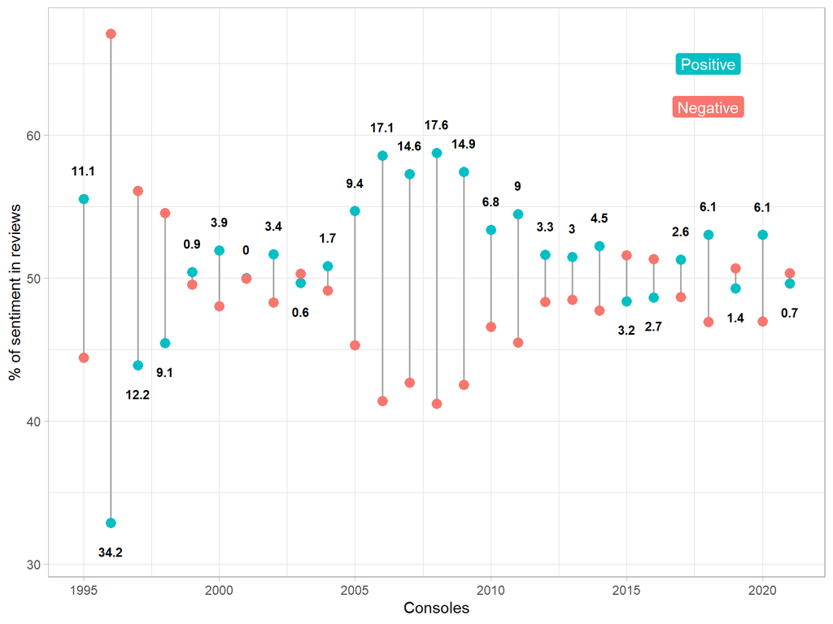

## Wordcloud

[interactive chart not shown]

## Fine

Grazie per l’attenzione.